# Lab 9 Assignment

## Problem 1:

Import the data from Flight Delays into R. Although the data are on all UA and AA flights flown in May and June of 2009, we will assume these represent a sample from a larger population of UA and AA flights flown under similar circumstances. We will consider the ratio of means of the flight delay lengths, $\mu UA/ \mu AA$.

```r
library(ggplot2)
library(boot)
df <- read.csv('./FlightDelays.csv')
```

1. Perform some exploratory data analysis(EDA) on flight delay lengths for each of UA and AA flights(look at some plots). Comment on your results.

```r
UA <- subset(df, df['Carrier']=='UA')
AA <- subset(df, df['Carrier']=='AA')
```

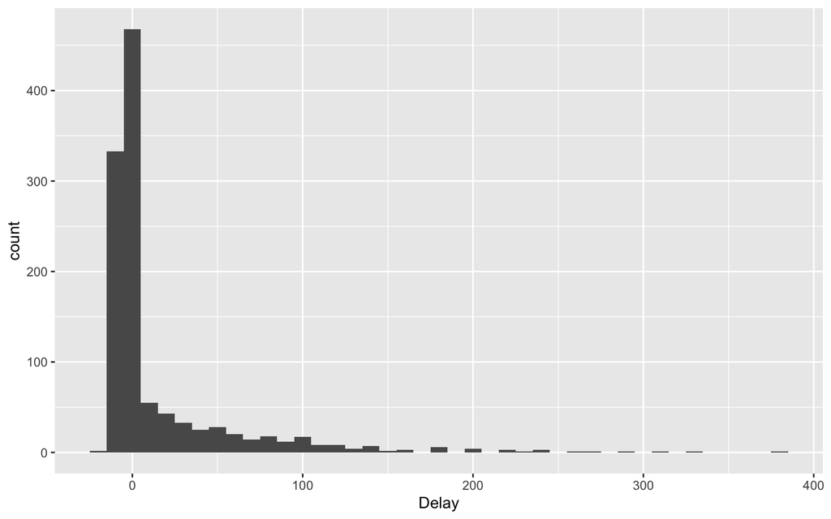

```r
ggplot(UA, aes(Delay)) +
  geom_histogram(binwidth=10)
```

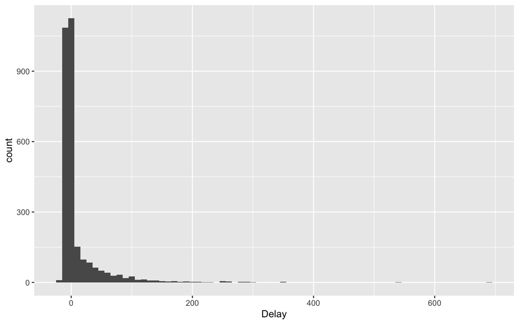

```r
ggplot(AA, aes(Delay)) +
  geom_histogram(binwidth = 10)
```

### Comments

AA has more records than UA, so we’ll have to bootstrap UA. In terms of the distributions, they’re both very similar. They look exponential and trails off after the 100-minute mark.

2. Bootstrap the mean of flight delay lengths for each airline separately and plot and describe the distribution.

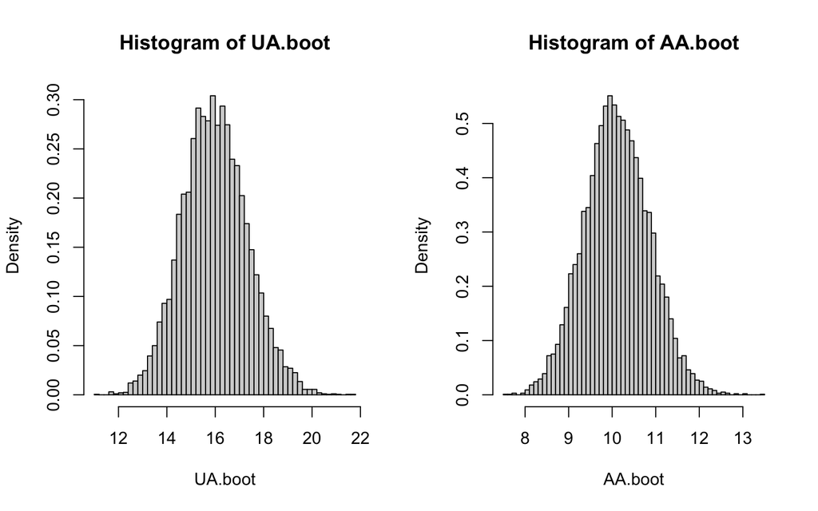

```r
# Using code from Prof. Gamage's slides
N <- 10000
delays.UA <- df$Delay[df$Carrier == 'UA']
delays.AA <- df$Delay[df$Carrier == 'AA']

n.UA <- length(delays.UA)
n.AA <- length(delays.AA)

UA.boot <- replicate(N,mean(sample(delays.UA, n.UA, replace=TRUE)))
AA.boot <- replicate(N,mean(sample(delays.AA, n.AA, replace=TRUE)))

par(mfrow = c(1,2))
hist(UA.boot, breaks = 50, prob=T)
hist(AA.boot, breaks = 50, prob=T)
```

### Describe distribution

The distributions are both normal, which is what we were hoping for.

3. Bootstrap the ratio of means. Provide plots of the bootstrap distribution and describe the distribution.

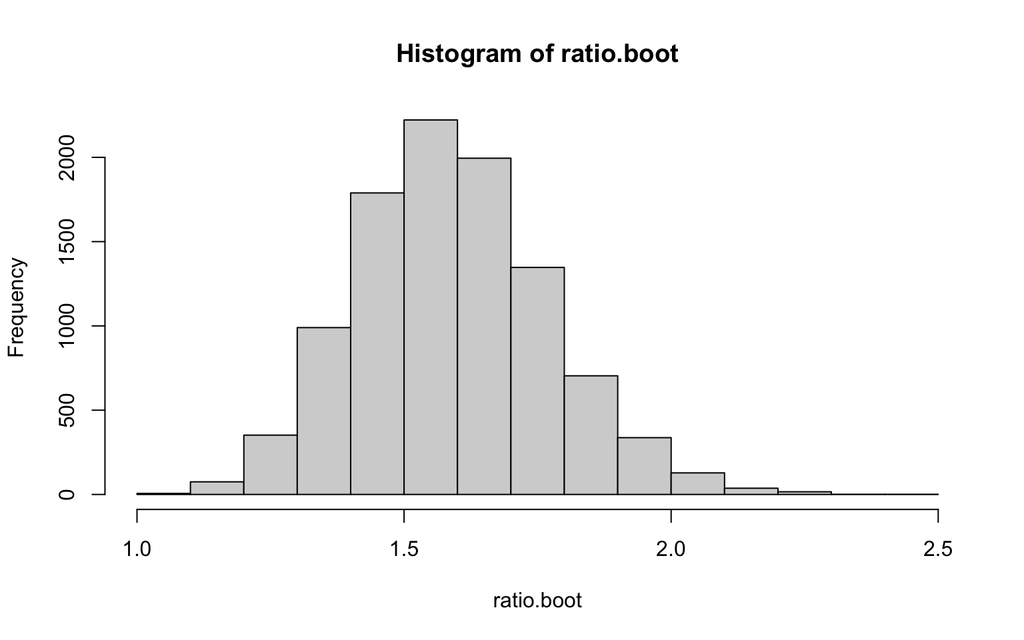

```r
ratio.boot <- UA.boot/AA.boot
hist(ratio.boot)
```

### Describe the distribution

Again, the distribution is close to normal, also what we were looking for.

4. Find the 95% bootstrap percentile interval for the ratio of means. Interpret this interval.

```r
quantile(ratio.boot, c(.025, .975))
```

```
##     2.5%    97.5%
## 1.261205 1.970443
```

5. What is the bootstrap estimate of the bias for the mean ratio?

```r
mean(ratio.boot)-(mean(delays.UA)/mean(delays.AA))
```

```
## [1] 0.006690097
```

## Problem 2: Hypothesis testing using bootstrap approach.

(Chihara2011)

Import the data set Titanic.csv which contains survival data (0 = death, 1 = survival) and ages of 658 passengers of the Titanic which sank on April 15, 1912 (the day when Americans had to file income tax returns for the first time). Examine the null hypothesis that the mean ages of survivors and of victims are the same against the alternative that these mean ages are different, using a bootstrap approach.

```r
Titanic = read.csv("Titanic.csv",stringsAsFactors=FALSE)
head(Titanic)
```

```
##   ID Survived   Age
## 1  1        1  0.92
## 2  2        0 30.00
## 3  3        1 48.00
## 4  4        0 39.00
## 5  5        0 71.00
## 6  6        0 47.00
```

Let’s make a hypothesis. Are two population means different?

Null Hypothesis: Mean ages of survivors and of victims are the same. (That means that there is no difference between the two population means)

Let’s use the bootstrap approach.

1. First let’s separate the two samples “survivors(=1)” and “victims(=0)”.

```r
t.survived <- Titanic$Age[Titanic$Survived == 1]
t.died <- Titanic$Age[Titanic$Survived == 0]
```

2. Make many bootstrap samples(100000) of difference of sample means.

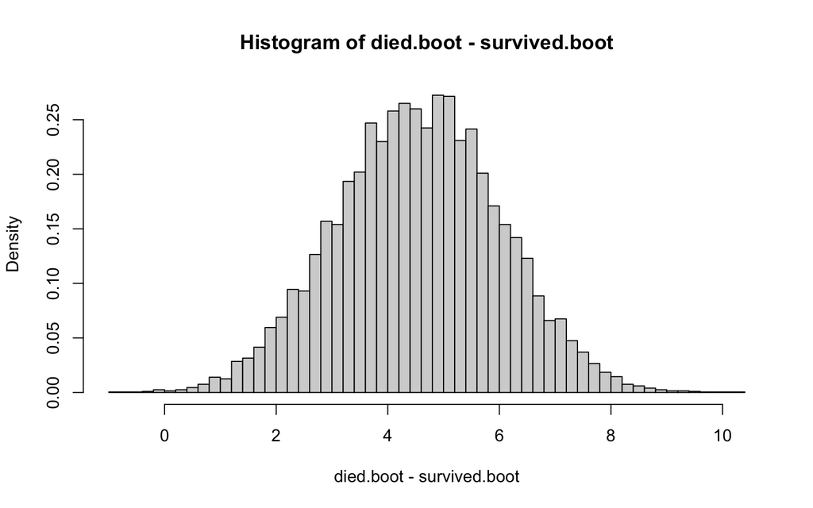

```r
n.t.survived <- length(t.survived)
n.t.died <- length(t.died)

survived.boot <- replicate(N,mean(sample(t.survived, n.t.survived, replace=TRUE)))
died.boot <- replicate(N,mean(sample(t.died, n.t.died, replace=TRUE)))

hist(died.boot-survived.boot, breaks = 50, prob=T)
```

```r
mean(died.boot-survived.boot)
```

```
## [1] 4.548339
```

3. Make a 90% percentile bootstrap confidence interval for the difference estimate. Using this CI, conclude on your hypothesis.

Null Hypothesis: Mean ages of survivors and of victims are the same. (That means that there is no difference between the two population means)

```r
ci.1 <- quantile((died.boot-survived.boot), c(.05, .95))
ci.1
```

```
##       5%      95%
## 2.124066 6.952683
```

4. Make a 95% percentile bootstrap confidence interval for the difference estimate and using this CI, conclude on your hypothesis.

```r
ci.2 <- quantile((died.boot-survived.boot), c(.025, .975))
ci.2
```

```
##     2.5%    97.5%
## 1.698871 7.379571
```

Null Hypothesis: Mean ages of survivors and of victims are the same. (That means that there is no difference between the two population means)

## Problem 3 (BONUS -5 points)

Load the Bangladesh data. We made inference about Arsenic in water in the Lab 9. Let’s make inference about Cobalt.

```r
bdesh <- read.csv("Bangladesh.csv")
head(bdesh)
```

```
##   Arsenic Chlorine Cobalt
## 1    2400      6.2   0.42
## 2       6    116.0   0.45
## 3     904     14.8   0.63
## 4     321     35.9   0.68
## 5    1280     18.9   0.58
## 6     151      7.8   0.35
```

1. Plot the boxplot of Cobalt. What’s look wrong? Do you think a transformation can explain the data better?

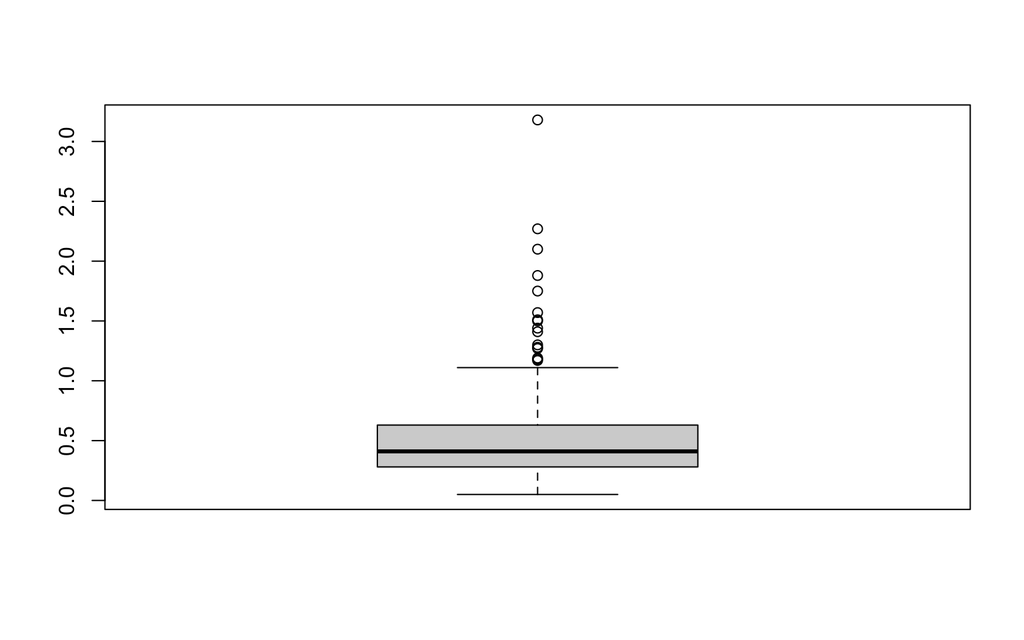

```r
boxplot(bdesh$Cobalt)
```

There seem to be a lot of outliers in the data, so it might not be a normal distribution. Also, the mean isn’t centerd, instead, it’s closer to the edge. A histogram would better visualize the distribution.

2. Make a log transformation of the data (Cobalt) and plot the boxplot. What do you see differently? Comment.

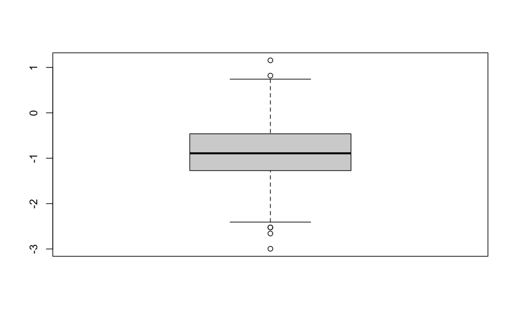

```r
log.cobalt <- log(bdesh$Cobalt)
boxplot(log.cobalt)
```

After the transformation, the boxplot is much closer to a normal distribution. Its mean is also closer to the middle and there are few outliers.

3. Are there an missing values? If so, remove the missing values and draw bootstrap samples(10000) of sample mean. (remember we are still using the log transformation)

```r
# check for missing values
colSums(is.na(bdesh))
```

```
##  Arsenic Chlorine   Cobalt
##        0        2        1
```

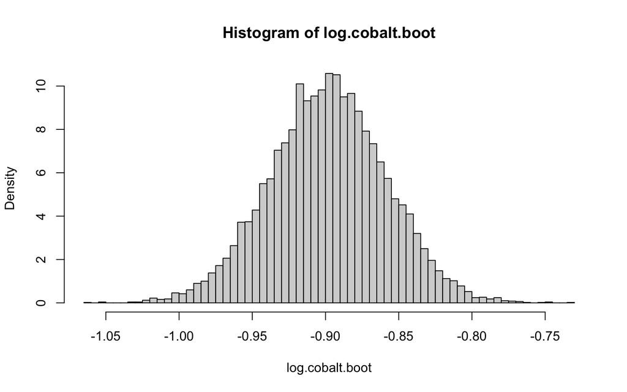

```r
# remove missing values
bdesh.2 <- bdesh[!is.na(bdesh$Cobalt),]
# add a row with the log values
bdesh.2$Cobalt.log <- log(bdesh.2$Cobalt)

# samples
bdesh2.logs <- bdesh.2$Cobalt.log
n.logs <- length(bdesh2.logs)

log.cobalt.boot <- replicate(10000, mean(sample(bdesh2.logs, n.logs, replace=TRUE)))

hist(log.cobalt.boot, breaks = 50, prob=T)
```

4. What is the bias?

```r
mean(log.cobalt.boot) - mean(bdesh2.logs)
```

```
## [1] 0.0002454872
```

5. Find the standard error of the bootstrap estimate.

```r
set.seed(42)
sd(log.cobalt.boot)
```

```
## [1] 0.0396988
```

Also, calculate the estimate(using the bootstrap sample) of mean squared error(MSE) =var(X)+ (bias)^2

```r
set.seed(42)
var(log.cobalt.boot) + (mean(log.cobalt.boot) - mean(bdesh2.logs))^2
```

```
## [1] 0.001576055
```

Comment on your results.

I’m actually a bit confused by the results and can’t make much sense of them. I tend to get confused when dealing with logs. I think there’s a small standard deviation for the bootstrap and the MSE seems to be close to 0%, so the predictions, or samples, are very similar to the real thing.

6. Make a 95% Percentile Bootstrap CI for mean of log transformed(log10) Cobalt data. Comment on your results.

```r
ci.3 <- quantile(log.cobalt.boot, c(.025, .975))
ci.3
```

```
##       2.5%      97.5%
## -0.9764707 -0.8210896
```

This is telling us that there is a 95% chance that the average log value of Cobalt in the wells will be between -0.98 and -0.82.

7. Repeat the bootstrap sampling process to estimate the median of the actual data(Cobalt- no transformation).

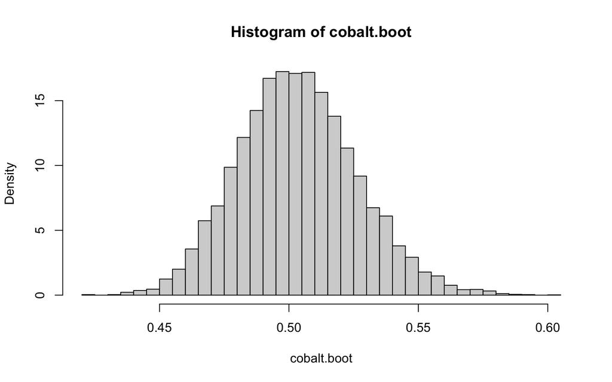

```r
# samples
bdesh2.cobalt <- bdesh.2$Cobalt
n.cobalt <- length(bdesh2.cobalt)

cobalt.boot <- replicate(10000, mean(sample(bdesh2.cobalt, n.cobalt, replace=TRUE)))

hist(cobalt.boot, breaks = 50, prob=T)
```

8. Find the bias and the standard error of the bootstrap estimate. Comment on your results.

```r
# bias
mean(cobalt.boot) - mean(bdesh2.cobalt)
```

```
## [1] -0.0002797444
```

The bias is almost nonexistent, which is expected after taking so many samples.

```r
# standard error
sd(cobalt.boot)
```

```
## [1] 0.02300377
```